# Kyle Hostetter's **Used Cars Price Prediction**

### **Model 1-Hyperparameter Tuning: Decision Tree**

```python
# Create the parameter grid based on the results of random search
param_grid = {
    'random_state': [0,5,10, 15],
    'max_depth': [5, 15, 20, 50, 100],
    'max_features': ['auto', 'sqrt', 'log2'],
    'min_samples_leaf':[5,10,15,20]
}

# Create a based model
dt_model = DecisionTreeRegressor(random_state=0)

# Instantiate the grid search model
grid_search = GridSearchCV(estimator = dt_model,
                           param_grid = param_grid,
                           cv = 3,
                           n_jobs = -1,
                           verbose = 2)

# Fit the grid search to the data
grid_search.fit(X_train1, y_train1)
```

```
Fitting 3 folds for each of 240 candidates, totalling 720 fits
```

```
GridSearchCV(cv=3, estimator=DecisionTreeRegressor(random_state=0), n_jobs=-1,
             param_grid={'max_depth': [5, 15, 20, 50, 100],
                         'max_features': ['auto', 'sqrt', 'log2'],
                         'min_samples_leaf': [5, 10, 15, 20],
                         'random_state': [0, 5, 10, 15]},
             verbose=2)
```

```python
# Print Model Parameters
print('\n\nBest Model Parameters')
print('-'*50)
print(grid_search.best_params_)

# Create Hypertuned Model
hypertuned_dt1 = grid_search.best_estimator_

# Evaluate Hypertuned vs. Default Regression Model
evaluate_hypertuned_model(model=dt_model,
                          hypertuned_model=hypertuned_dt1,
                          model_name= 'Decision Tree Regressor',
                          folds=3,
                          X_train=X_train1,
                          y_train=y_train1,
                          X_test=X_test1,
                          y_test=y_test1)
```

```
Best Model Parameters
--------------------------------------------------
{'max_depth': 20, 'max_features': 'auto', 'min_samples_leaf': 5, 'random_state': 10}


                                  CROSS VALIDATION REPORT
-----------------------------------------------------------------------------------------
```

|  | Model | R-Squared | Mean Absolute Error | Mean Squared Error |
| --- | --- | --- | --- | --- |
| 1 | Hypertuned Decision Tree Regressor | 0.860 | 0.093 | 0.210 |
| 0 | Default Decision Tree Regressor | 0.846 | 0.102 | 0.219 |

```
                                  REGRESSION FINAL REPORT
---------------------------------------------------------------------------------------------
Training Set Size: 4109
Testing Set Size: 1761
```

|  | Model | R-Squared | Mean Absolute Error | Mean Squared Error |
| --- | --- | --- | --- | --- |
| 1 | Hypertuned Decision Tree Regressor | 0.877 | 0.198 | 0.279 |
| 0 | Default Decision Tree Regressor | 0.872 | 0.200 | 0.286 |

**Model 1-Hypertuning Observations**-

- We can see that there was a significant increase in R-Squared score, for the cross-validation.
- There was also an increase in the R-squared score for the final testing model.
- We will be continuing with hypertuned model here.

**Model 1- Decision Tree Feature Importance**

|  | Feature | Importance |
| --- | --- | --- |
| 3 | Power | 0.607384 |
| 0 | Year | 0.260905 |
| 2 | Engine | 0.048473 |
| 5 | log_Kilometers_Driven | 0.018325 |
| 1 | Mileage | 0.017169 |
| 48 | Transmission_Manual | 0.006424 |
| 13 | Manufacturer_Honda | 0.004590 |
| 41 | Location_Kolkata | 0.004485 |
| 23 | Manufacturer_Mini | 0.003235 |
| 4 | Seats | 0.003078 |
| 30 | Manufacturer_Tata | 0.002607 |
| 50 | Owner_Type_Second | 0.002552 |
| 44 | Fuel_Type_Diesel | 0.002411 |
| 38 | Location_Hyderabad | 0.002322 |
| 36 | Location_Coimbatore | 0.002190 |
| 31 | Manufacturer_Toyota | 0.001715 |
| 20 | Manufacturer_Mahindra | 0.001530 |
| 6 | Manufacturer_Audi | 0.001278 |
| 51 | Owner_Type_Third | 0.001064 |
| 8 | Manufacturer_Chevrolet | 0.001004 |
| 39 | Location_Jaipur | 0.000986 |
| 47 | Fuel_Type_Petrol | 0.000756 |
| 22 | Manufacturer_Mercedes-Benz | 0.000717 |
| 21 | Manufacturer_Maruti | 0.000665 |
| 12 | Manufacturer_Ford | 0.000656 |
| 42 | Location_Mumbai | 0.000653 |
| 37 | Location_Delhi | 0.000591 |
| 34 | Location_Bangalore | 0.000520 |
| 43 | Location_Pune | 0.000423 |
| 14 | Manufacturer_Hyundai | 0.000323 |
| 28 | Manufacturer_Skoda | 0.000302 |
| 40 | Location_Kochi | 0.000297 |
| 32 | Manufacturer_Volkswagen | 0.000223 |
| 35 | Location_Chennai | 0.000118 |
| 27 | Manufacturer_Renault | 0.000028 |
| 9 | Manufacturer_Datsun | 0.000000 |
| 10 | Manufacturer_Fiat | 0.000000 |
| 46 | Fuel_Type_LPG | 0.000000 |
| 49 | Owner_Type_Fourth & Above | 0.000000 |
| 7 | Manufacturer_BMW | 0.000000 |
| 45 | Fuel_Type_Electric | 0.000000 |
| 19 | Manufacturer_Land | 0.000000 |
| 11 | Manufacturer_Force | 0.000000 |
| 18 | Manufacturer_Jeep | 0.000000 |
| 33 | Manufacturer_Volvo | 0.000000 |
| 15 | Manufacturer_ISUZU | 0.000000 |
| 29 | Manufacturer_Smart | 0.000000 |
| 16 | Manufacturer_Isuzu | 0.000000 |
| 25 | Manufacturer_Nissan | 0.000000 |
| 24 | Manufacturer_Mitsubishi | 0.000000 |
| 17 | Manufacturer_Jaguar | 0.000000 |
| 26 | Manufacturer_Porsche | 0.000000 |

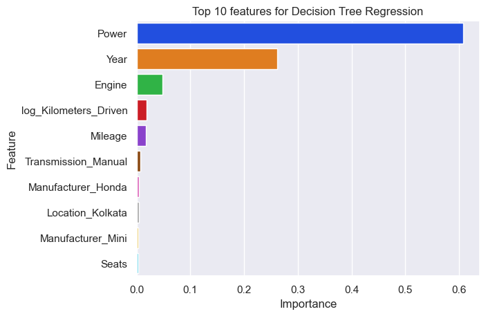

```python
# Show importance of features for Decision Tree
tree_regression_importance(hypertuned_dt1,                           # Best performing regression model
                           X_train=X_train1,                         # X_train data
                           y_train=y_train1,                         # y_train data
                           top_values=10,                           # Top # of features
                           model_name='Decision Tree Regression')   # Name of Tree Regression model
```

**Model 1-Decision Tree Importance Observations**-

- We can see that Power and Year are the 2 more important variables for this model. We know that Power had the highest correlation with Price when comparing the values earlier.
- One thing to note as well is that most manufacturers do not give any significant value to this model.

### **Model 1-Hypertuning Ridge Regression**

```python
# Ridge Regression Parameter grid
param_grid = {'solver':['svd', 'cholesky', 'lsqr', 'sag'],
              'alpha': [1e-5, 1e-4, 1e-3, 1e-2, 1e-1, 1, 10, 100],
              'fit_intercept':[True, False],
              'normalize':[True, False]}

# Create a based model
ridge_model = Ridge()

# Instantiate the grid search model
grid_search = GridSearchCV(estimator = ridge_model,
                           param_grid = param_grid,
                           cv = 3,
                           n_jobs = -1,
                           verbose = 2)

# Fit the grid search to the data
grid_search.fit(X_train1, y_train1)
```

```
Fitting 3 folds for each of 128 candidates, totalling 384 fits
```

```
GridSearchCV(cv=3, estimator=Ridge(), n_jobs=-1,
             param_grid={'alpha': [1e-05, 0.0001, 0.001, 0.01, 0.1, 1, 10, 100],
                         'fit_intercept': [True, False],
                         'normalize': [True, False],
                         'solver': ['svd', 'cholesky', 'lsqr', 'sag']},
             verbose=2)
```

```python
print('\n\nBest Model Parameters')
print('-'*50)
print(grid_search.best_params_)

hypertuned_ridge = grid_search.best_estimator_

# Evaluate Hypertuned Model
evaluate_hypertuned_model(model=ridge_model,
                          hypertuned_model=hypertuned_ridge,
                          model_name='Ridge Regression',
                          folds=3,
                          X_train=X_train1,
                          y_train=y_train1,
                          X_test=X_test1,
                          y_test=y_test1)
```

```
Best Model Parameters
--------------------------------------------------
{'alpha': 1, 'fit_intercept': True, 'normalize': False, 'solver': 'cholesky'}


                                  CROSS VALIDATION REPORT
-----------------------------------------------------------------------------------------
```

|  | Model | R-Squared | Mean Absolute Error | Mean Squared Error |
| --- | --- | --- | --- | --- |
| 0 | Default Ridge Regression | 0.908 | 0.061 | 0.18 |
| 1 | Hypertuned Ridge Regression | 0.908 | 0.061 | 0.18 |

```
                                  REGRESSION FINAL REPORT
---------------------------------------------------------------------------------------------
Training Set Size: 4109
Testing Set Size: 1761
```

|  | Model | R-Squared | Mean Absolute Error | Mean Squared Error |
| --- | --- | --- | --- | --- |
| 0 | Default Ridge Regression | 0.91 | 0.181 | 0.239 |
| 1 | Hypertuned Ridge Regression | 0.91 | 0.181 | 0.239 |

**Model 1- Hypertuning Ridge regression Observations**-

- We can see that there is no difference in R-squared during this process. So in the next model we will not run hyper turning on this model.

## **Model 2**

### **Model 2- Encoding Process**

```python
# Create copy of dataframe
df_copy2 = df_copy.copy()

# Maps for dataframe
transmission = {'Automatic': 2,
                'Manual': 1}

owner_type = {'First': 4,
              'Second':	3,
              'Third': 2,
              'Fourth & Above': 1}

fuel_type = {'Electric': 5,
             'Diesel': 4,
             'Petrol': 3,
             'CNG': 2,
             'LPG': 1}

location = {'Coimbatore': 11,
	        'Bangalore': 10,
	        'Kochi': 9,
	        'Hyderabad': 8,
	        'Delhi': 7,
	        'Mumbai': 6,
	        'Ahmedabad': 5,
	        'Chennai': 4,
	        'Pune': 3,
	        'Jaipur': 2,
	        'Kolkata': 1}

manufacturers = {'Porsche':29,
                 'Land': 28,
                 'Jaguar': 27,
                 'Mini': 26,
                 'Audi': 25,
                 'Mercedes-Benz': 24,
                 'BMW': 23,
                 'Isuzu': 22,
                 'Volvo': 21,
                 'Jeep': 20,
                 'ISUZU': 19,
                 'Toyota': 18,
                 'Mitsubishi': 17,
                 'Force': 16,
                 'Mahindra': 15,
                 'Skoda': 14,
                 'Ford': 13,
                 'Renault': 12,
                 'Honda': 11,
                 'Hyundai': 10,
                 'Volkswagen': 9,
                 'Nissan': 8,
                 'Maruti': 7,
                 'Tata': 6,
                 'Fiat': 5,
                 'Datsun': 4,
                 'Chevrolet': 3,
                 'Smart': 2,
                 'Ambassador': 1}

# Encode based on what categories have highest average price from EDA
df_copy2['Transmission'] = df_copy2['Transmission'].map(transmission)
df_copy2['Owner_Type'] = df_copy2['Owner_Type'].map(owner_type)
df_copy2['Fuel_Type'] = df_copy2['Fuel_Type'].map(fuel_type)
df_copy2['Location'] = df_copy2['Location'].map(location)
df_copy2['Manufacturer'] = df_copy2['Manufacturer'].map(manufacturers)

display(df_copy2)
```

|  | Name | Location | Year | Kilometers_Driven | Fuel_Type | Transmission | Owner_Type | Mileage | Engine | Power | Seats | Price | Manufacturer | log_Kilometers_Driven | log_Price |
| --- | --- | --- | --- | --- | --- | --- | --- | --- | --- | --- | --- | --- | --- | --- | --- |
| 0 | Maruti Wagon R LXI CNG | 6 | 2010 | 72000 | 2 | 1 | 4 | 26.60 | 998.0 | 58.16 | 5.0 | 1.75 | 7 | 11.184421 | 0.559616 |
| 1 | Hyundai Creta 1.6 CRDi SX Option | 3 | 2015 | 41000 | 4 | 1 | 4 | 19.67 | 1582.0 | 126.20 | 5.0 | 12.50 | 10 | 10.621327 | 2.525729 |
| 2 | Honda Jazz V | 4 | 2011 | 46000 | 3 | 1 | 4 | 18.20 | 1199.0 | 88.70 | 5.0 | 4.50 | 11 | 10.736397 | 1.504077 |
| 3 | Maruti Ertiga VDI | 4 | 2012 | 87000 | 4 | 1 | 4 | 20.77 | 1248.0 | 88.76 | 7.0 | 6.00 | 7 | 11.373663 | 1.791759 |
| 4 | Audi A4 New 2.0 TDI Multitronic | 11 | 2013 | 40670 | 4 | 2 | 3 | 15.20 | 1968.0 | 140.80 | 5.0 | 17.74 | 25 | 10.613246 | 2.875822 |
| ... | ... | ... | ... | ... | ... | ... | ... | ... | ... | ... | ... | ... | ... | ... | ... |
| 6014 | Maruti Swift VDI | 7 | 2014 | 27365 | 4 | 1 | 4 | 28.40 | 1248.0 | 74.00 | 5.0 | 4.75 | 7 | 10.217020 | 1.558145 |
| 6015 | Hyundai Xcent 1.1 CRDi S | 2 | 2015 | 100000 | 4 | 1 | 4 | 24.40 | 1120.0 | 71.00 | 5.0 | 4.00 | 10 | 11.512925 | 1.386294 |
| 6016 | Mahindra Xylo D4 BSIV | 2 | 2012 | 55000 | 4 | 1 | 3 | 14.00 | 2498.0 | 112.00 | 8.0 | 2.90 | 15 | 10.915088 | 1.064711 |
| 6017 | Maruti Wagon R VXI | 1 | 2013 | 46000 | 3 | 1 | 4 | 18.90 | 998.0 | 67.10 | 5.0 | 2.65 | 7 | 10.736397 | 0.974560 |
| 6018 | Chevrolet Beat Diesel | 8 | 2011 | 47000 | 4 | 1 | 4 | 25.44 | 936.0 | 57.60 | 5.0 | 2.50 | 3 | 10.757903 | 0.916291 |

5870 rows × 15 columns

```python
# Create testing and Training Datasets
X2 = df_copy2.drop(['Price', 'Kilometers_Driven', 'Name', 'log_Price'], axis=1)
y2 = df_copy2['log_Price']

# Split Training & Testing sets
X_train2, X_test2, y_train2, y_test2 = train_test_split(X2,                 # Independent variable
                                                        y2,                 # Dependent variable
                                                        test_size=0.3,      # Set test percentage
                                                        random_state = 0,   # Sets the random seed for consitant results
                                                        shuffle=True)       # Shuffles dataset
```

### **Model 2-Regression Analysis**

```python
# Use basic regression models
basic_regression(model_list=regressor,       # Regression models
                 name_list=regressor_name,   # List of names of regression models
                 X_train=X_train2,           # X_train data
                 y_train=y_train2,           # y_train data
                 X_test=X_test2,             # X_test data
                 y_test=y_test2)             # y_test data
```

```
                                 REGRESSION FINAL REPORT
---------------------------------------------------------------------------------------------
Training Set Size: 4109
Testing Set Size: 1761
```

|  | Model | Time_Taken | R-Squared | Mean Absolute Error | Root Mean Squared Error |
| --- | --- | --- | --- | --- | --- |
| 4 | Random Forest Regression | 1.1 | 0.936049 | 0.143171 | 0.201629 |
| 0 | Ridge Regression | 0.0 | 0.883862 | 0.210369 | 0.271717 |
| 2 | Linear Regression | 0.0 | 0.883854 | 0.210383 | 0.271726 |
| 3 | Decision Tree Regression | 0.0 | 0.882430 | 0.189693 | 0.273387 |
| 1 | Lasso Regression | 0.0 | 0.666365 | 0.350522 | 0.460538 |

### **Model 2- Cross Validation**

```python
# Run Cross Validation
cross_val_regression(model_list=regressor,      # Regression models
                     name_list=regressor_name,  # List of names of regression models
                     X_train=X_train2,           # X_train data
                     y_train=y_train2,           # y_train data
                     folds=10)                  # of kfolds to use in cross validation
```

```
                                 CROSS VALIDATION REPORT
-----------------------------------------------------------------------------------------
```

|  | Model | Time_Taken | R-Squared | Mean Squared Error | Mean Absolute Error |
| --- | --- | --- | --- | --- | --- |
| 4 | Random Forest Regression | 6.4 | 0.936 | 0.142 | 0.042 |
| 0 | Ridge Regression | 0.1 | 0.884 | 0.207 | 0.076 |
| 2 | Linear Regression | 0.1 | 0.884 | 0.207 | 0.076 |
| 3 | Decision Tree Regression | 0.1 | 0.872 | 0.198 | 0.085 |
| 1 | Lasso Regression | 0.1 | 0.662 | 0.357 | 0.224 |

**Model 2-Cross_Validation Observations**-

- Here we can see that the order of models is still the same, but we see that most models stayed the same or worsened with cross validation. This is calculated by comparing the R-squared scores.

### **Model 2-Hyperparameter Tuning: Random Forest**

```python
# Create the parameter grid based on the results of random search
param_grid = {
    'random_state': [0,5,10],
    'max_depth': [5, 20, 50, 100],
    'max_features': [2, 3, 5],
    'min_samples_leaf': [3, 4, 5],
    'min_samples_split': [8, 10, 12],
    'n_estimators': [30, 50, 150, 200]
}

# Create a based model
rf_model = RandomForestRegressor(random_state=0)

# Instantiate the grid search model
grid_search = GridSearchCV(estimator = rf_model,
                           param_grid = param_grid,
                           cv = 3,
                           n_jobs = -1,
                           verbose = 2)

# Fit the grid search to the data
grid_search.fit(X_train2, y_train2)
```

```
Fitting 3 folds for each of 1296 candidates, totalling 3888 fits
```

```
GridSearchCV(cv=3, estimator=RandomForestRegressor(random_state=0), n_jobs=-1,
             param_grid={'max_depth': [5, 20, 50, 100],
                         'max_features': [2, 3, 5],
                         'min_samples_leaf': [3, 4, 5],
                         'min_samples_split': [8, 10, 12],
                         'n_estimators': [30, 50, 150, 200],
                         'random_state': [0, 5, 10]},
             verbose=2)
```

```python
# Print Model Parameters
print('Best Model Parameters')
print('-'*50)
print(grid_search.best_params_)

hypertuned_rf = grid_search.best_estimator_

# Evaluate Hypertuned vs. Default Regression Model
evaluate_hypertuned_model(model=rf_model,
                          hypertuned_model=hypertuned_rf,
                          model_name= 'Random Forest Regressor',
                          folds=10,
                          X_train=X_train2,
                          y_train=y_train2,
                          X_test=X_test2,
                          y_test=y_test2)
```

```
Best Model Parameters
--------------------------------------------------
{'max_depth': 20, 'max_features': 5, 'min_samples_leaf': 3, 'min_samples_split': 8, 'n_estimators': 200, 'random_state': 5}


                                  CROSS VALIDATION REPORT
-----------------------------------------------------------------------------------------
```

|  | Model | R-Squared | Mean Absolute Error | Mean Squared Error |
| --- | --- | --- | --- | --- |
| 0 | Default Random Forest Regressor | 0.936 | 0.042 | 0.142 |
| 1 | Hypertuned Random Forest Regressor | 0.935 | 0.043 | 0.146 |

```
                                  REGRESSION FINAL REPORT
---------------------------------------------------------------------------------------------
Training Set Size: 4109
Testing Set Size: 1761
```

|  | Model | R-Squared | Mean Absolute Error | Mean Squared Error |
| --- | --- | --- | --- | --- |
| 0 | Default Random Forest Regressor | 0.936 | 0.143 | 0.202 |
| 1 | Hypertuned Random Forest Regressor | 0.936 | 0.147 | 0.202 |

### **Model 2-Random Forest Feature Importance**

|  | Feature | Importance |
| --- | --- | --- |
| 7 | Power | 0.498064 |
| 1 | Year | 0.245831 |
| 9 | Manufacturer | 0.151971 |
| 6 | Engine | 0.035757 |
| 0 | Location | 0.020924 |
| 10 | log_Kilometers_Driven | 0.018485 |
| 5 | Mileage | 0.015795 |
| 3 | Transmission | 0.004117 |
| 8 | Seats | 0.003805 |
| 2 | Fuel_Type | 0.002692 |
| 4 | Owner_Type | 0.002560 |

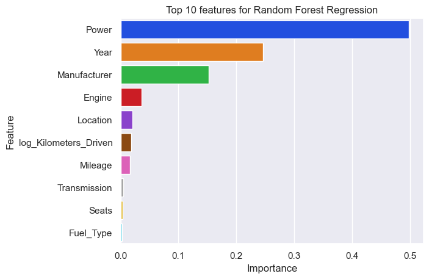

```python
# Show Importance Information
tree_regression_importance(rf_model,                                # Best performing regression model
                           X_train=X_train2,                         # X_train data
                           y_train=y_train2,                         # y_train data
                           top_values=10,                           # Top # of features
                           model_name='Random Forest Regression')   # Name of Tree Regression model
```

**Model 2-Feature Importance Observations**-

- We saw as in Random Forest Regression that power was the largest predictor when it come to price. This again could be because of the high correlation between Price and Power that we saw earlier in the heatmap.
- We can see that there is more importance on the manufacturers here in this model.
- Year still is the second most important predictor for both models through.

### **Model 2-Hyperparameter Tuning: Decision Tree**

```python
# Create the parameter grid based on the results of random search
param_grid = {
    'random_state': [0,5,10, 15],
    'max_depth': [5, 15, 20, 50, 100],
    'max_features': ['auto', 'sqrt', 'log2'],
    'min_samples_leaf':[5,10,15,20]
}

# Create a based model
dt_model = DecisionTreeRegressor(random_state=0)

# Instantiate the grid search model
grid_search = GridSearchCV(estimator = dt_model,
                           param_grid = param_grid,
                           cv = 3,
                           n_jobs = -1,
                           verbose = 2)

# Fit the grid search to the data
grid_search.fit(X_train2, y_train2)
```

```
Fitting 3 folds for each of 240 candidates, totalling 720 fits
```

```
GridSearchCV(cv=3, estimator=DecisionTreeRegressor(random_state=0), n_jobs=-1,
             param_grid={'max_depth': [5, 15, 20, 50, 100],
                         'max_features': ['auto', 'sqrt', 'log2'],
                         'min_samples_leaf': [5, 10, 15, 20],
                         'random_state': [0, 5, 10, 15]},
             verbose=2)
```

```python
# Print Model Parameters
print('\n\nBest Model Parameters')
print('-'*50)
print(grid_search.best_params_)

# Create Hypertuned Model
hypertuned_dt2 = grid_search.best_estimator_

# Evaluate Hypertuned vs. Default Regression Model
evaluate_hypertuned_model(model=dt_model,
                          hypertuned_model=hypertuned_dt2,
                          model_name= 'Decision Tree Regressor',
                          folds=3,
                          X_train=X_train2,
                          y_train=y_train2,
                          X_test=X_test2,
                          y_test=y_test2)
```

```
Best Model Parameters
--------------------------------------------------
{'max_depth': 15, 'max_features': 'auto', 'min_samples_leaf': 5, 'random_state': 0}


                                  CROSS VALIDATION REPORT
-----------------------------------------------------------------------------------------
```

|  | Model | R-Squared | Mean Absolute Error | Mean Squared Error |
| --- | --- | --- | --- | --- |
| 1 | Hypertuned Decision Tree Regressor | 0.885 | 0.076 | 0.196 |
| 0 | Default Decision Tree Regressor | 0.867 | 0.088 | 0.207 |

```
                                  REGRESSION FINAL REPORT
---------------------------------------------------------------------------------------------
Training Set Size: 4109
Testing Set Size: 1761
```

|  | Model | R-Squared | Mean Absolute Error | Mean Squared Error |
| --- | --- | --- | --- | --- |
| 1 | Hypertuned Decision Tree Regressor | 0.893 | 0.185 | 0.261 |
| 0 | Default Decision Tree Regressor | 0.882 | 0.190 | 0.273 |

**Model 2-Hypertuning Observations**-

- We can see that there was a significant increase in R-Squared score, for the cross-validation.
- There was also an increase in the R-squared score for the final testing model.

### **Model 2-Decision Tree Importance**

|  | Feature | Importance |
| --- | --- | --- |
| 7 | Power | 0.573671 |
| 1 | Year | 0.250642 |
| 9 | Manufacturer | 0.082294 |
| 6 | Engine | 0.039165 |
| 0 | Location | 0.019874 |
| 5 | Mileage | 0.016080 |
| 10 | log_Kilometers_Driven | 0.012638 |
| 3 | Transmission | 0.002752 |
| 4 | Owner_Type | 0.001374 |
| 2 | Fuel_Type | 0.000957 |
| 8 | Seats | 0.000553 |

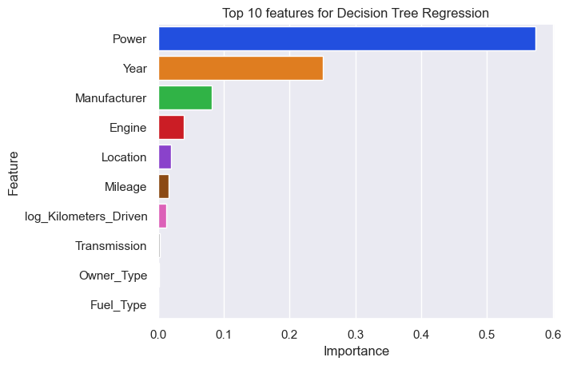

```python
# Show importance of features for Decision Tree
tree_regression_importance(hypertuned_dt2,                           # Best performing regression model
                           X_train=X_train2,                         # X_train data
                           y_train=y_train2,                         # y_train data
                           top_values=10,                           # Top # of features
                           model_name='Decision Tree Regression')   # Name of Tree Regression model
```

**Model 2-Decision Tree Importance Observations**-

- We can see that Power and Year are the 2 more important variables for this model. We know that Power had the highest correlation with Price when comparing the values earlier.

## Model Comparisons

**Final Training & Testing/Cross Validation Comparison**

```python
# Print Model 1
print('MODEL 1')
print('*'*80)

# Define all Machine Learning Regression Models
regressor1 = [ Ridge(random_state=0),
              Lasso(random_state=0),
              LinearRegression(),
              hypertuned_dt1,
              RandomForestRegressor(random_state=0)]

regressor_name1 = [ 'Ridge Regression',
                   'Lasso Regression',
                   'Linear Regression',
                   'Hypertuned Decision Tree Regression',
                   'Random Forest Regression']


# Use basic regression models FOR MODEL 2
basic_regression(model_list=regressor1,       # Regression models
                 name_list=regressor_name1,   # List of names of regression models
                 X_train=X_train1,           # X_train data
                 y_train=y_train1,           # y_train data
                 X_test=X_test1,             # X_test data
                 y_test=y_test1)             # y_test data

# Print Space
print('\n')

# Run Cross Validation
cross_val_regression(model_list=regressor1,      # Regression models
                     name_list=regressor_name1,  # List of names of regression models
                     X_train=X_train1,           # X_train data
                     y_train=y_train1,           # y_train data
                     folds=10)                  # of kfolds to use in cross validation

# Print Model 2
print('\n\nMODEL 2')
print('*'*80)

# Define all Machine Learning Regression Models
regressor2 = [ Ridge(random_state=0),
              Lasso(random_state=0),
              LinearRegression(),
              hypertuned_dt2,
              RandomForestRegressor(random_state=0)]

regressor_name2 = [ 'Ridge Regression',
                   'Lasso Regression',
                   'Linear Regression',
                   'Hypertuned Decision Tree Regression',
                   'Random Forest Regression']


# Use basic regression models FOR MODEL 2
basic_regression(model_list=regressor2,       # Regression models
                 name_list=regressor_name2,   # List of names of regression models
                 X_train=X_train2,           # X_train data
                 y_train=y_train2,           # y_train data
                 X_test=X_test2,             # X_test data
                 y_test=y_test2)             # y_test data

# Print Space
print('\n')

# Run Cross Validation
cross_val_regression(model_list=regressor2,      # Regression models
                     name_list=regressor_name2,  # List of names of regression models
                     X_train=X_train2,           # X_train data
                     y_train=y_train2,           # y_train data
                     folds=10)                  # of kfolds to use in cross validation
```

```
MODEL 1
                                 REGRESSION FINAL REPORT
---------------------------------------------------------------------------------------------
Training Set Size: 4109
Testing Set Size: 1761
```

|  | Model | Time_Taken | R-Squared | Mean Absolute Error | Root Mean Squared Error |
| --- | --- | --- | --- | --- | --- |
| 4 | Random Forest Regression | 1.6 | 0.929146 | 0.151314 | 0.212233 |
| 2 | Linear Regression | 0.0 | 0.911105 | 0.180680 | 0.237721 |
| 0 | Ridge Regression | 0.0 | 0.910487 | 0.181136 | 0.238547 |
| 3 | Hypertuned Decision Tree Regression | 0.0 | 0.877170 | 0.198266 | 0.279436 |
| 1 | Lasso Regression | 0.0 | 0.666365 | 0.350522 | 0.460538 |

```
                                 CROSS VALIDATION REPORT
-----------------------------------------------------------------------------------------
```

|  | Model | Time_Taken | R-Squared | Mean Squared Error | Mean Absolute Error |
| --- | --- | --- | --- | --- | --- |
| 4 | Random Forest Regression | 9.1 | 0.928 | 0.149 | 0.048 |
| 0 | Ridge Regression | 0.1 | 0.909 | 0.179 | 0.060 |
| 2 | Linear Regression | 0.1 | 0.908 | 0.179 | 0.060 |
| 3 | Hypertuned Decision Tree Regression | 0.1 | 0.867 | 0.206 | 0.088 |
| 1 | Lasso Regression | 0.1 | 0.662 | 0.357 | 0.224 |

```
MODEL 2
                                 REGRESSION FINAL REPORT
---------------------------------------------------------------------------------------------
Training Set Size: 4109
Testing Set Size: 1761
```

|  | Model | Time_Taken | R-Squared | Mean Absolute Error | Root Mean Squared Error |
| --- | --- | --- | --- | --- | --- |
| 4 | Random Forest Regression | 1.1 | 0.936049 | 0.143171 | 0.201629 |
| 3 | Hypertuned Decision Tree Regression | 0.0 | 0.893058 | 0.185377 | 0.260738 |
| 0 | Ridge Regression | 0.0 | 0.883862 | 0.210369 | 0.271717 |
| 2 | Linear Regression | 0.0 | 0.883854 | 0.210383 | 0.271726 |
| 1 | Lasso Regression | 0.0 | 0.666365 | 0.350522 | 0.460538 |

```
                                 CROSS VALIDATION REPORT
-----------------------------------------------------------------------------------------
```

|  | Model | Time_Taken | R-Squared | Mean Squared Error | Mean Absolute Error |
| --- | --- | --- | --- | --- | --- |
| 4 | Random Forest Regression | 5.9 | 0.936 | 0.142 | 0.042 |
| 3 | Hypertuned Decision Tree Regression | 0.1 | 0.891 | 0.189 | 0.072 |
| 0 | Ridge Regression | 0.1 | 0.884 | 0.207 | 0.076 |
| 2 | Linear Regression | 0.1 | 0.884 | 0.207 | 0.076 |
| 1 | Lasso Regression | 0.1 | 0.662 | 0.357 | 0.224 |

## **Conclusions and Recommendations**

**1. Comparison of various techniques and their relative performance based on chosen Metric (Measure of success):**

- How do different techniques perform? Which one is performing relatively better? Is there scope to improve the performance further?
- Answer: The main difference between the two models are the encoding methods.
- Model 1: used pd.dummies to encode the dataframe. This was so that all categorical variables were give same values of importance from the start.
- Model 2: The encoding method for model 2 was to encode the the categorical variables by there average price. This way there could be more importance given to the categorical variables that had a higher average price.

**2. Refined insights:**

- What are the most meaningful insights relevant to the problem?
- Answer: That the log transformation can give huge insights to normal distribution patterns in independent variables.
- Power is the most important feature in the 2 highest performing models. This was infered earlier when looking at the heatmap correlations between Power and log_Price.

**3. Proposal for the final solution design:**

- What model do you propose to be adopted? Why is this the best solution to adopt?
- **Model 2 Random Forest Regression: The reason for this is that the Random Forest Regression model has the higher performance based on R-squared score from any other model. After running both models through cross validation model2's Random Forest Regression's R-squared score remained the same. Judging by this information, I found that model 2 Random forest regression was the best perfoming model and should be adopted as the final solution with an R-squared score of .936!**

## Exectutive Summary

The important findings for this are that Power, Year and Manufacturer are the 3 largest predictors when it comes to used car predictions. The next steps would be to see how we can input current market conditions that include supply and demand. This would give a higher accuracy to our predictions in this model. The final model is stated above and shows that the model 2 and encoding process will be the best way to predict used car prices.

The only challenges would be to see how these predictions were correlated with new car price. The only costs that would be associated with this model would be the server to run the model on and the web scraping software needed to pull on information for this prediction model.